# Clustering Customers for Segmentation

Chase Baggett

# Introduction

I am going to be using clustering techniques to attempt customer segmentation on a dataset of purchasing data for an online retailer. Specifically, I am analyzing customer spending patterns and habits.

# Data

```r
data <-
  summarise(
  group_by(eretail, CustomerID, Country),
  Quantity = sum(Quantity),
  Unique_Items = n_distinct(StockCode),
  Spend = sum(UnitPrice * Quantity),
  Transactions = n_distinct(InvoiceNo),
  Days_Age = as.numeric(difftime(max(InvoiceDate),min(InvoiceDate),units="days"))
  )
data <- data[complete.cases(data),]
```

I am going to prep a few different variables on this dataset.

| Field | Description |
| --- | --- |
| Spend | Total Money Spent |
| Transactions | Number of Invoices |
| Quantity | Number of Products Purchased |
| Unique_Items | Number of Unique Items Purchased |
| Days_Age | Number of Days From First to Last Purchase |

# Analysis

A basic summary of our variables makes it apparent that there are a large number of customers who placed a very small numbers of orders, had a very low age, and few transactions. In fact, 35% of customers only had one transaction.

```r
pl_dat <- data[,c("Quantity","Transactions","Spend","Unique_Items","Days_Age")]
summary(pl_dat)
```

```
##     Quantity       Transactions        Spend            Unique_Items
##  Min.   :     1   Min.   :  1.00   Min.   :0.000e+00   Min.   :   1.00
##  1st Qu.:   156   1st Qu.:  1.00   1st Qu.:8.636e+03   1st Qu.:  15.00
##  Median :   367   Median :  2.00   Median :4.300e+04   Median :  34.00
##  Mean   :  1139   Mean   :  4.13   Mean   :1.852e+06   Mean   :  60.04
##  3rd Qu.:   950   3rd Qu.:  4.00   3rd Qu.:2.382e+05   3rd Qu.:  76.00
##  Max.   :189533   Max.   :201.00   Max.   :1.920e+09   Max.   :1734.00
##     Days_Age
##  Min.   :  0.00
##  1st Qu.:  0.00
##  Median : 83.14
##  Mean   :125.22
##  3rd Qu.:245.05
##  Max.   :364.05
```

Viewing the remaining 65%, I’m going to log transform and scale all variables except Days_Age, which I will only scale. We have massively right tailed data and I am hoping that by using a log transformation the clusters we end up with will be logical.

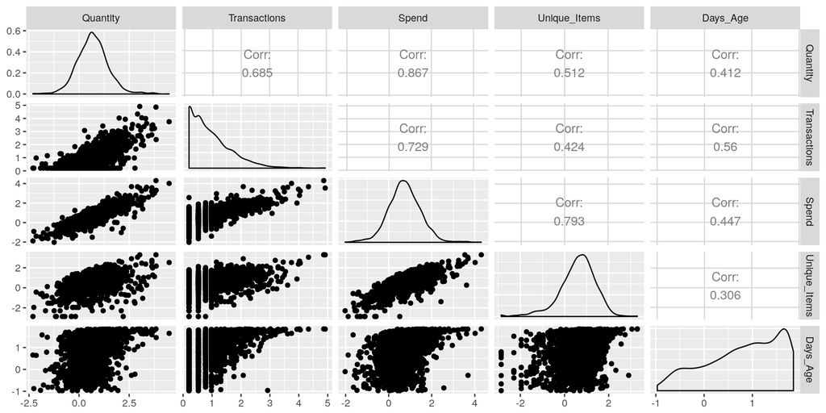

```r
log_zero <- function(x){ifelse(x==0,0,log(x))}

pl_dat$Quantity <- log_zero(pl_dat$Quantity)
pl_dat$Transactions <- log_zero(pl_dat$Transactions)
pl_dat$Spend <- log_zero(pl_dat$Spend)
pl_dat$Unique_Items <- log_zero(pl_dat$Unique_Items)
pl_dat <- as.data.frame(scale(pl_dat))
ggpairs(subset(pl_dat,Transactions>log(1)))
```

## Hierarchical Clustering

First I perform a basic hierarchical clustering and look at the dendrogram to identify a cut point.

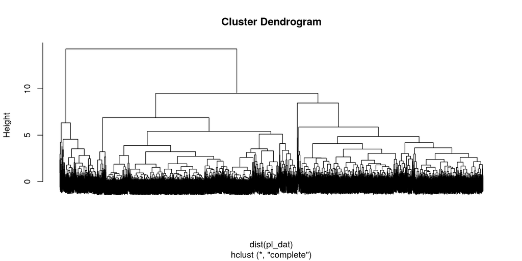

```r
hc <- hclust(dist(pl_dat))
plot(hc,labels=FALSE)
```

Now I am going to cut the tree down to 5 clusters and store the classification.

We can take a look at a pairs plot of the scaled variables colored by classification.

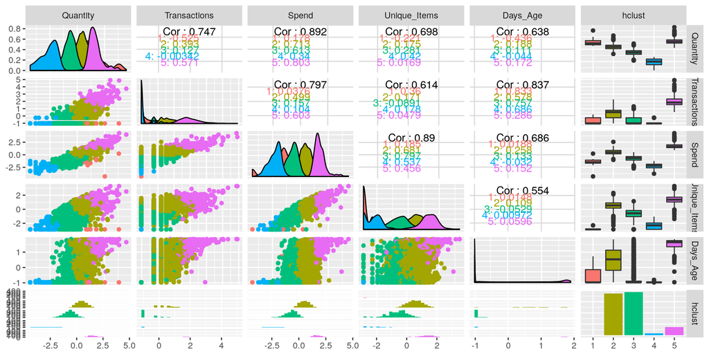

```r
pl_dat$hclust <- as.factor(cutree(hc,5))
ggpairs(pl_dat,mapping=aes(color=hclust))
```

## K-Means Clustering

We will now use K-Means as well, using the 5 cluster we indentified using hierarchical clustering.

Below, we see the results on the K-Means on our scaled data.

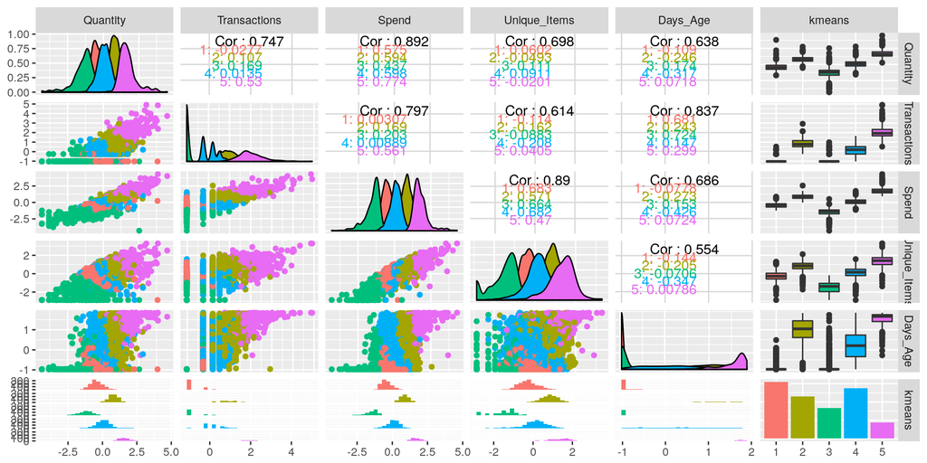

```r
pl_dat <- data[,c("Quantity","Transactions","Spend","Unique_Items","Days_Age")]


log_zero <- function(x){ifelse(x==0,0,log(x))}

pl_dat$Quantity <- log_zero(pl_dat$Quantity)
pl_dat$Transactions <- log_zero(pl_dat$Transactions)
pl_dat$Spend <- log_zero(pl_dat$Spend)
pl_dat$Unique_Items <- log_zero(pl_dat$Unique_Items)
pl_dat <- as.data.frame(scale(pl_dat))

set.seed(1)
km <- kmeans(pl_dat,centers = 5)
pl_dat$kmeans <- as.factor(km$cluster)
ggpairs(pl_dat,mapping=aes(color=kmeans))
```

# Conclusion

We can see that we have some significant differences between k-means and hierarchical clustering. Most notably, kmeans has put the data into much closer to evenly sized clusters, whereas hclust, at the cut point I chose, places most data points into two clusters.

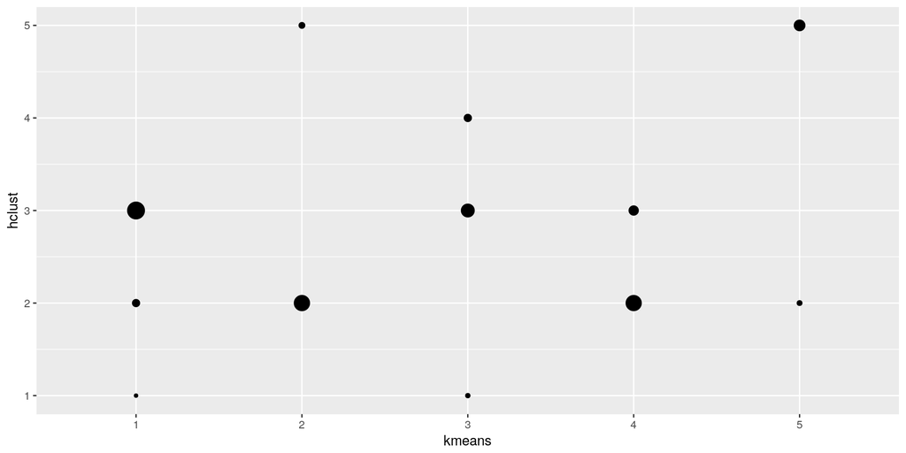

```r
pl_dat$hclust <- cutree(hc,5)
res <- summarise(group_by(pl_dat,hclust,kmeans),cnt=n())
res <- res[order(res$cnt,decreasing = T),]
ggplot(res,aes(y=hclust,x=kmeans,size=cnt)) +
  geom_point() +
  theme(legend.position = "none")
```

We are going to look at hclust cluster #2, which is broken into 4 kmeans clusters. We can see that it is broken apart in what appears to be a very spherical way.

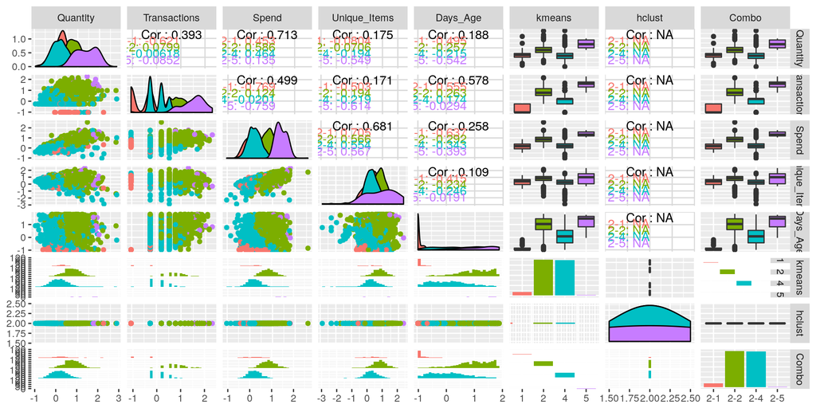

```r
pl_dat$Combo <- paste(pl_dat$hclust,pl_dat$kmeans,sep="-")
ggpairs(subset(pl_dat,hclust==2),mapping=aes(color=Combo))
```

I am going to use the kmeans clustering from here on out. Using hclust to determine the number of clusters but using the underlying machinery of K-Means.

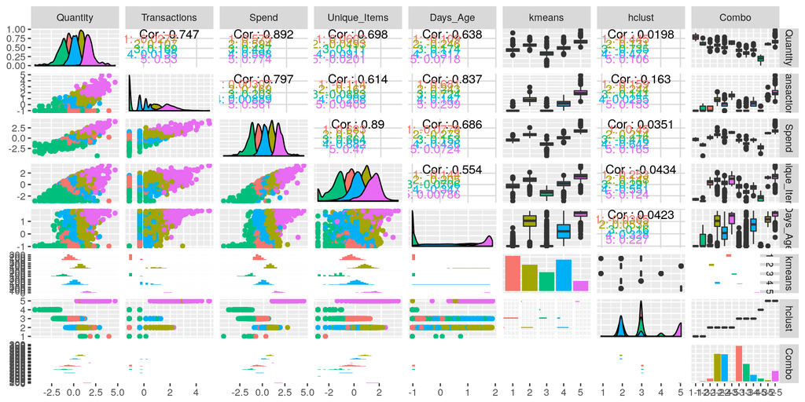

```r
final_dat <-
  data[, c("Quantity",
  "Transactions",
  "Spend",
  "Unique_Items",
  "Days_Age")]
final_dat <- round(final_dat,2)
  final_dat$hclust <- as.factor(pl_dat$hclust)
  final_dat$kmeans <- as.factor(pl_dat$kmeans)

ggpairs(pl_dat,mapping=aes(color=kmeans))
```

With k means, the most desirable cluster for a customer to have is cluster 5, because is the highest spending, highest volume cluster.

```r
  datatable(
  summarise(
  group_by(final_dat, kmeans),
  Transactions = round(mean(Transactions),2),
  Spend = round(mean(Spend),2),
  Unique_Items = round(mean(Unique_Items),2),
  Days_Age = round(mean(Days_Age),2)
  )
  )
```

|  | kmeans | Transactions | Spend | Unique_Items | Days_Age |
| --- | --- | --- | --- | --- | --- |
| 1 | 1 | 1.22 | 23999.2 | 28.78 | 8.12 |
| 2 | 2 | 5.84 | 550795.53 | 100.27 | 250.16 |
| 3 | 3 | 1.25 | 2036.44 | 6.45 | 17.1 |
| 4 | 4 | 2.96 | 90258.2 | 45.67 | 154.66 |
| 5 | 5 | 18.98 | 20730281.26 | 211.19 | 322.58 |

We can then show which countries comprise the underlying clusters.

```r
sankey_data <- pl_dat
sankey_data$Country <- data$Country
#sankey_data <- subset(sankey_data,Country!="United Kingdom")
top_countries <- summarise(group_by(sankey_data,Country),Cnt=n())
top_countries <- top_countries[order(top_countries$Cnt,decreasing = T),]$Country
sankey_data <- subset(sankey_data,Country %in% head(top_countries,25))
sankey_data$H1 <- paste("hclust",sankey_data$hclust)
sankey_data$H2 <- paste("kmeans",sankey_data$kmeans)
links1 <- sankey_data[,c("H2","Country")]
#links2 <- sankey_data[,c("Country","H2")]
colnames(links1) <- c("From","To")
#colnames(links2) <- c("From","To")
#links <- rbind(links1,links2)
links <- links1
nodes <- data.frame(node=unique(c(as.character(links$From),as.character(links$To))))
nodes$ID <- 1:nrow(nodes) - 1
colnames(nodes) <- c("From","Source")
links <- merge(nodes,links,by="From")
colnames(nodes) <- c("To","Target")
links <- merge(nodes,links,by="To")
links$value <- 1
nodes$name <- nodes$To

links <- summarise(group_by(links,Source,Target),value=sum(value))
sankeyNetwork(Links = links, Nodes = nodes, Source = "Source",
              Target = "Target", Value = "value", NodeID = "name",
              fontSize = 12, nodeWidth = 30)
```

[interactive chart not shown]